##### **Fig. C.7:** Conditional distribution(s) of current and prior scale scores: American Lit.

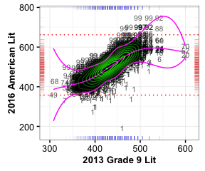

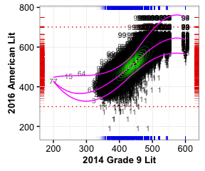

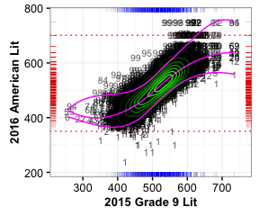

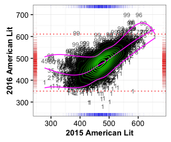

##### **Fig. C.8:** Conditional distribution(s) of current and prior scale scores: US History.

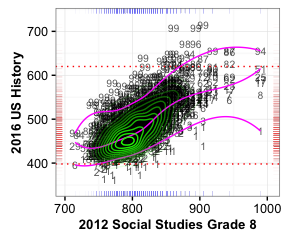

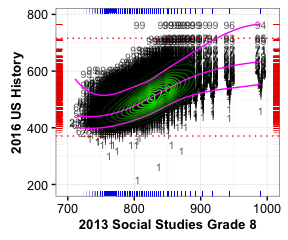

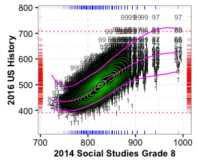

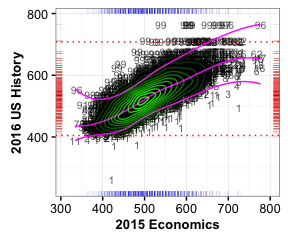

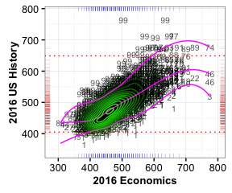

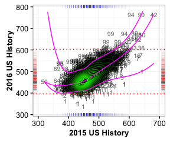

##### **Fig. C.9:** Conditional distribution(s) of current and prior scale scores: Economics.

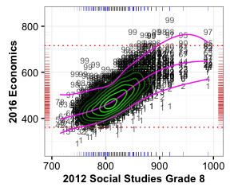

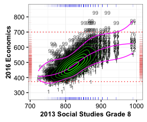

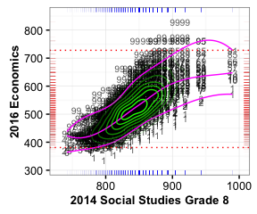

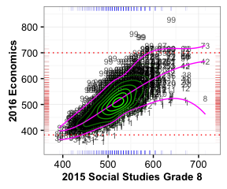

##### **Fig. C.10:** Conditional distribution(s) of current and prior scale scores: Economics *Continued*.

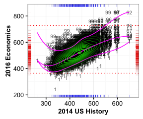

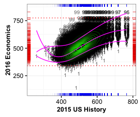

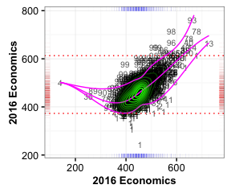

##### **Fig. C.11:** Conditional distribution(s) of current and prior scale scores: Biology.

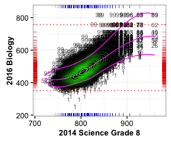

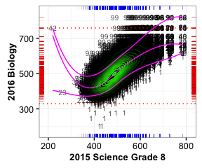

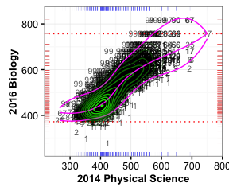

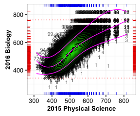

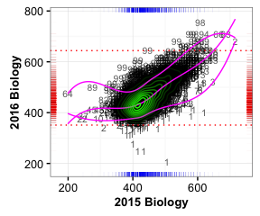

##### **Fig. C.12:** Conditional distribution(s) of current and prior scale scores: Physical Science.

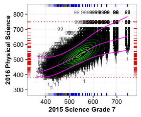

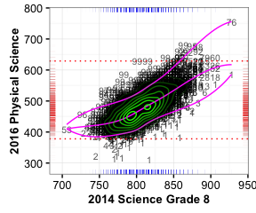

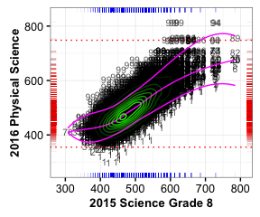

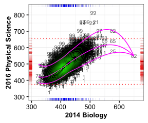

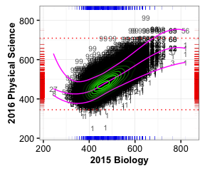

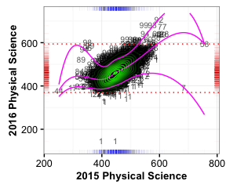

##### **Fig. C.13:** Conditional distribution(s) of current and prior scale scores: Coordinate Algebra.

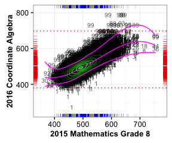

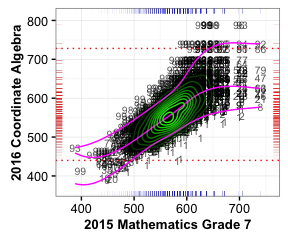

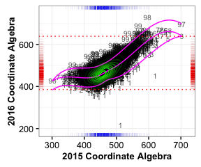

##### **Fig. C.14:** Conditional distribution(s) of current and prior scale scores: Analytic Geometry.

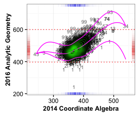

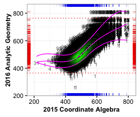

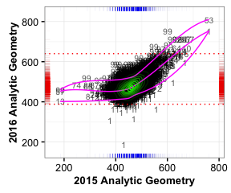

##### **Fig. C.15:** Conditional distribution(s) of current and prior scale scores: Algebra I.

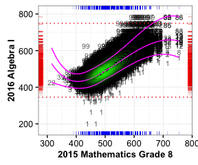

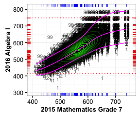

##### **Fig. C.16:** Conditional distribution(s) of current and prior scale scores: Geometry.

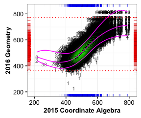

# 3 SGP Ranges for the Highest and Lowest Achieving Students

In order to isolate the impact of assessment ceilings/floors on student growth percentile (SGP) calculations, the following section provides box plots of the distribution of SGPs for the highest and lowest achieving students. We are specifically interested in the growth percentiles for students scoring at the highest/lowest obtainable scale score (HOSS/LOSS - i.e. the artificial test ceiling/floor) on the current year test. However, in order to assure that an adequate number of students are included, the first set of plots in each subsection uses, at a *minimum*, the highest/lowest 25 scores. This roughly corresponds to the number of students in the top and bottom rows of the table included in the SGP model goodness of fit plots, which is why these plots are provided as a starting point here. All students with a score in these students’ range of scores are included. Consequently, the number of students in each box plot may be greater than 25 (the exact number is shown at the margins in red text).

The second set of box plots in the following subsections isolate *only* those students scoring the HOSS/LOSS. These plots may then incorporate a varying number of students depending on the prevalence of a ceiling/floor in the current year. The SIMEX measurement error corrected SGP is Georgia’s official growth metric, and these values are used exclusively in this report.

The box plots provide several descriptive statistics. The dark line within the box marks the *median* SGP, while the ends (“hinges”) of the boxes correspond to the first and third quartiles (the 25<sup>th</sup> and 75<sup>th</sup> percentiles). The upper whisker extends from the hinge to the highest value that is within 1.5 $×$ IQR of the hinge, where IQR is the inter-quartile range, or distance between the first and third quartiles. The lower whisker extends from the hinge to the lowest value within 1.5 $×$ IQR of the hinge. Data beyond the end of the whiskers are outliers and plotted as points. Evidence of a *lack* of either a ceiling or floor effect would be to have all high achieving students with SGPs near 99 and all low achieving students with SGPs near 1. That is, the desired visual evidence is a solid line at SGP = 99/1.

In the 2016 Georgia EOG SGP analyses, we see evidence of a very minor ceiling effects in some grades and content areas. These issues are present when considering the top 25 students’ scores, but are mitigated when considering only the HOSS/LOSS scores. The vast majority of SGPs are as expected for students at the score extremes (see Figure C.18).

## 3.1 EOG Content Areas

##### **Fig. C.17:** EOG SGP distributions for highest and lowest 25+ scale scores by content area and grade level.

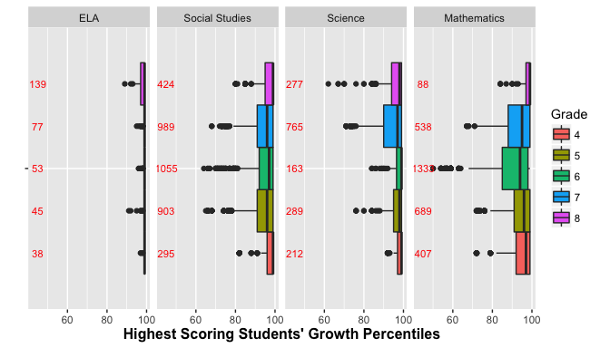

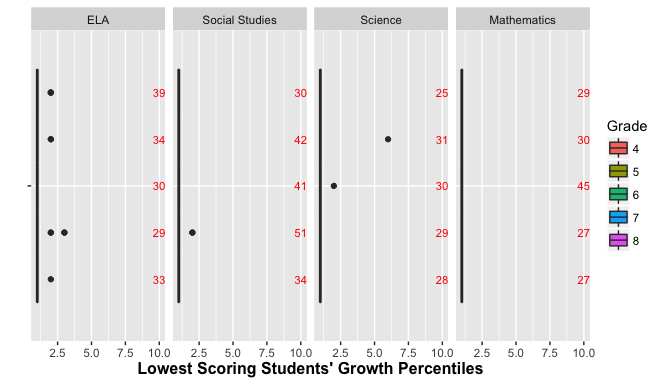

##### **Fig. C.18:** EOG SGP distributions for the HOSS and LOSS scores by content area and grade level.

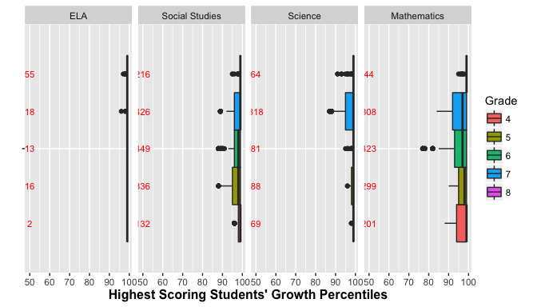

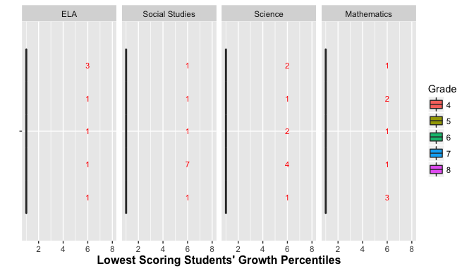

## 3.2 EOC Subjects

The end-of-course subject results are shown here *only for students scoring exactly the HOSS and LOSS* respectively. There are several subjects for which potential ceiling effects are evident. All EOC subjects are disaggregated further by the most recent prior test included in each analyses in order to adequately address any concerns.

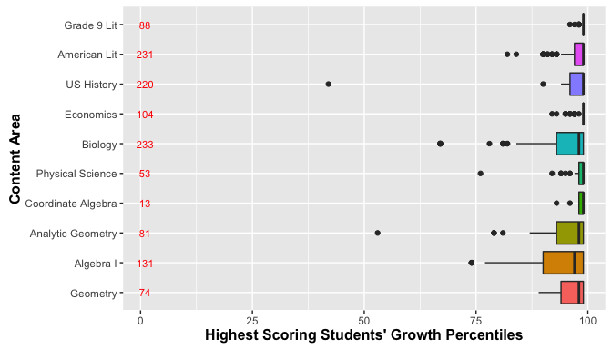

The end-of-course box plots can be disaggregated further by the most recent prior to reflect their constituent norm groups more closely. The following box plots disaggregate each EOC subject by norm groups. A pattern emerges in these plots suggesting that the course repeater and those that included skipped years are the most problematic.

##### **Fig. C.20:** EOC SGP distributions for the HOSS and LOSS scores by norm group: 9<sup>th</sup> Grade Literature.

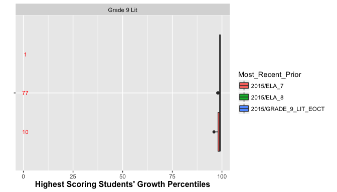

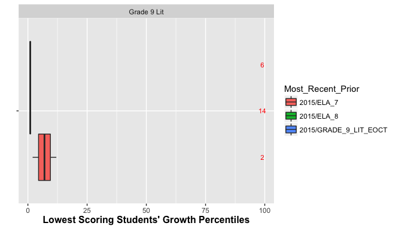

##### **Fig. C.21:** EOC SGP distributions for the HOSS and LOSS scores by norm group: American Lit.

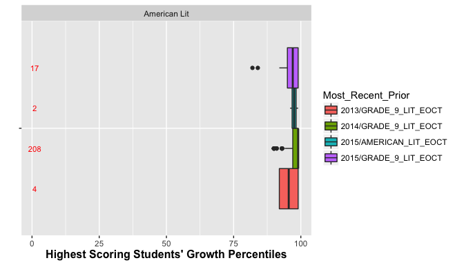

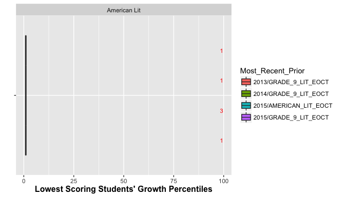

In the US History plots below we see the potentially problematic single case from the course repeater analysis (highlighted earlier in the bottom-right panel of Figure C.8). This student has scored perfectly on both tests (which begs the question as to why this student was re-taking the test to begin with), and, given her relation to the rest of this cohort, the SGP model has estimated this to be a relatively common occurrence with an SGP of 42. This may be a fair assessment of the conditional probability of staying perfect, but it may not necessarily be a good description of this student’s growth.

##### **Fig. C.22:** EOC SGP distributions for the HOSS and LOSS scores by norm group: US History.

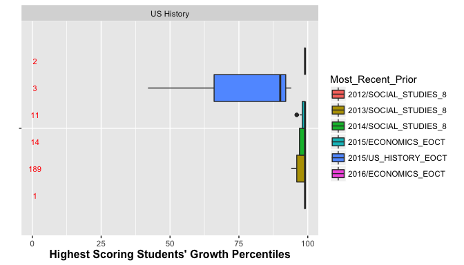

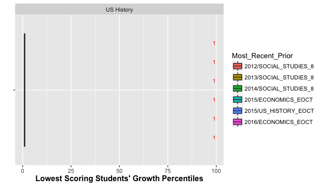

##### **Fig. C.23:** EOC SGP distributions for the HOSS and LOSS scores by norm group: Economics.

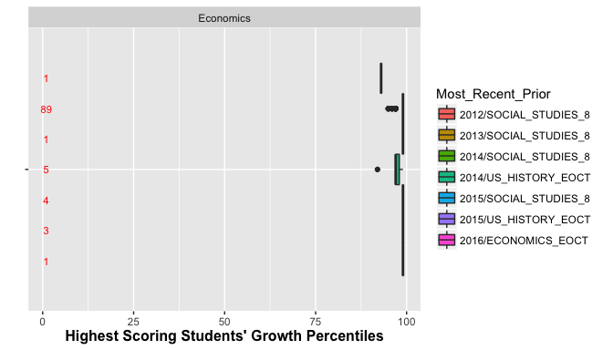

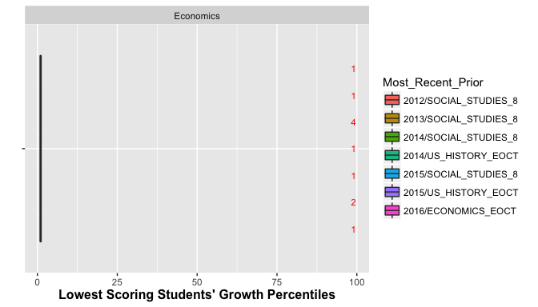

Several plots for Biology are notable, particularly for the Physical Science prior progressions. These progressions both show some minor ceiling issues. This is most likely due to the relatively high number of students attaining the HOSS in 2016 Biology, which deflates the SGPs of those students with relatively higher prior Physical Science scores. Although not as high as the ideal, these students’ SGPs are still on the higher end of the spectrum.

##### **Fig. C.24:** EOC SGP distributions for the HOSS and LOSS scores by norm group: Biology.

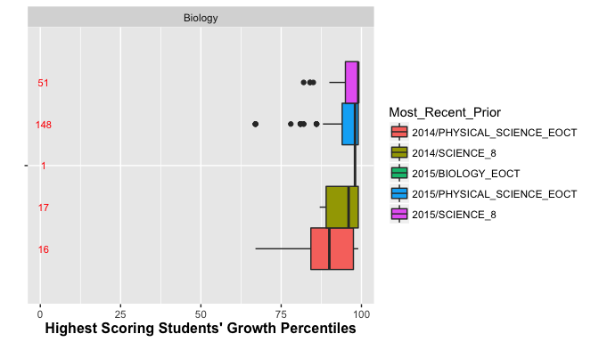

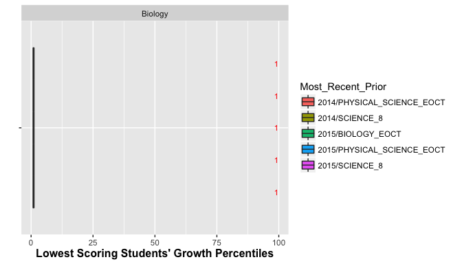

In Physical Science we see one student in a skipped-year (8<sup>th</sup> Grade Science prior) progression that has a lower than desirable SGP (76) despite scoring at the HOSS for two consecutive years. This student is an outlier in the data and it is not surprising that the SGP estimate of her growth is questionable.